# Final2_Qichao_Huang

```python
import numpy as np
import pandas as pd
import matplotlib.pyplot as plt
%matplotlib inline
import datetime
from datetime import date
import statsmodels.api as sm
import scipy as sp
import statsmodels.tsa.stattools as ts
from sklearn.linear_model import LinearRegression
```

```python
df = pd.read_csv("Constant_Maturity_EDs.csv",index_col=[0])
df.index = map(lambda x:datetime.datetime.strptime(x,"%m/%d/%y").date(),df.index)
df.head()
```

|  | 0.25Y | 0.5Y | 0.75Y | 1.0Y | 1.25Y | 1.5Y | 1.75Y | 2.0Y | 2.25Y | 2.5Y | 2.75Y | 3.0Y | 3.25Y | 3.5Y | 3.75Y | 4.0Y | 4.25Y | 4.5Y | 4.75Y |
| --- | --- | --- | --- | --- | --- | --- | --- | --- | --- | --- | --- | --- | --- | --- | --- | --- | --- | --- | --- |
| 2000-01-03 | 6.284949 | 6.584670 | 6.812857 | 7.012308 | 7.037857 | 7.121429 | 7.170769 | 7.222582 | 7.186538 | 7.196538 | 7.214890 | 7.259725 | 7.239121 | 7.263297 | 7.294066 | 7.359066 | 7.363407 | 7.405604 | 7.447802 |
| 2000-01-04 | 6.266224 | 6.537857 | 6.768846 | 6.957473 | 6.983846 | 7.066923 | 7.117363 | 7.172088 | 7.136648 | 7.146648 | 7.164670 | 7.204396 | 7.184396 | 7.208516 | 7.239945 | 7.304011 | 7.308901 | 7.350934 | 7.393791 |
| 2000-01-05 | 6.282857 | 6.586923 | 6.825440 | 7.008516 | 7.040659 | 7.128242 | 7.184066 | 7.243462 | 7.216758 | 7.227637 | 7.251209 | 7.294066 | 7.274670 | 7.299670 | 7.336813 | 7.403956 | 7.409396 | 7.452308 | 7.500879 |
| 2000-01-06 | 6.281837 | 6.567912 | 6.796044 | 6.968736 | 7.001703 | 7.089670 | 7.149945 | 7.207088 | 7.176868 | 7.187802 | 7.211868 | 7.253736 | 7.234945 | 7.258956 | 7.292747 | 7.358901 | 7.364890 | 7.407692 | 7.456923 |
| 2000-01-07 | 6.271888 | 6.530440 | 6.755495 | 6.913956 | 6.947747 | 7.033407 | 7.086813 | 7.146648 | 7.116978 | 7.127967 | 7.152527 | 7.193407 | 7.175220 | 7.199176 | 7.233681 | 7.298846 | 7.305385 | 7.348077 | 7.397967 |

```python
SampleA = df.loc[datetime.date(2011,6,1):datetime.date(2014,1,31)].dropna()
SampleB = df.loc[datetime.date(2014,6,1):datetime.date(2015,6,30)].dropna()
SampleC = df.loc[datetime.date(2015,6,1):datetime.date(2016,6,30)].dropna()
```

```python
from statsmodels.tsa.ar_model import AR
from statsmodels.tsa.stattools import adfuller

def CCA_BT(dataset):

    X=dataset.iloc[:-1]#.as_matrix()
    Y=dataset.iloc[1:]#.as_matrix()

    A=np.linalg.lstsq(X,Y)[0]
    cov=Y.cov()
    M=np.linalg.inv(cov).dot(A.T.dot(cov.dot(A)))
    xcv_COINT,vcv_COINT=np.linalg.eig(M)
    return xcv_COINT,vcv_COINT

def half_life(x,dt=1./260):
    x = list(x)
    X=sm.add_constant(x[:-1])
    Y=x[1:]
    res = sm.OLS(Y,X).fit()
    R = res.params[1]
    half_life = np.log(0.5)/np.log(R)*dt
    return half_life

#compute the weight and the cointegrated vector
def coint_vec(dataset):
    val, _ =CCA_BT(dataset)
    w = [1.,-val[1]/val[0]]
    res_vect = dataset.dot(w)
    return w,res_vect

def AR_model(coint_vec):
    ar_model = AR(coint_vec.as_matrix())
    ar_res = ar_model.fit(maxlag = 1)
    return ar_res

def optimize_alpha(coint_vec):
    return sp.optimize.fsolve(lambda a:half_life(coint_vec-coint_vec.ewm(span=a).mean())-10./260.,15)[0]

def simple_AR(coint_data):
    res = {}
    w,res_vect = coint_vec(coint_data)

    ar_res_coint = AR_model(res_vect)
    alpha = optimize_alpha(res_vect)
    EMA_coint_data = res_vect-res_vect.ewm(span=alpha).mean()
    ar_res_EMA = AR_model(EMA_coint_data)
    return w,alpha,res_vect,EMA_coint_data,ar_res_coint,ar_res_EMA

def print_AR_HL(res):
    w,alpha,res_vect,EMA_coint_data,ar_res_coint,ar_res_EMA = res
    print "weight for the coint vector",w
    print "AR parameter for cointegrated vector:",ar_res_coint.params
    print "AR parameter for EMA:",ar_res_EMA.params
    print "alpha:",2./(alpha+1)
    print "half life for coint vec:",half_life(res_vect)
    print "half life for coint vec-EMA(alpha)",half_life(res_vect-res_vect.ewm(span=alpha).mean()),"\n"
    pass
```

```python
coint_time = [['2.0Y','3.0Y'],['3.0Y','4.0Y'],['4.0Y','4.75Y']]
result_AR=[]
for time in coint_time:
    result_AR.append(simple_AR(SampleA[time]));

for time,tmp in zip(coint_time,result_AR):
    print time
    print_AR_HL(tmp)
```

```
['2.0Y', '3.0Y']
weight for the coint vector [1.0, -0.95241782290896759]
AR parameter for cointegrated vector: [-0.00232096  0.99624939]
AR parameter for EMA: [ -1.18010626e-04   9.33032992e-01]
alpha: 0.0633810505175
half life for coint vec: 0.70947101274
half life for coint vec-EMA(alpha) 0.0384615384615

['3.0Y', '4.0Y']
weight for the coint vector [1.0, -1.0628035118180674]
AR parameter for cointegrated vector: [-0.00500382  0.99425   ]
AR parameter for EMA: [  7.21281952e-05   9.33032992e-01]
alpha: 0.0603069775935
half life for coint vec: 0.462309587503
half life for coint vec-EMA(alpha) 0.0384615384615

['4.0Y', '4.75Y']
weight for the coint vector [1.0, -1.0392689764374814]
AR parameter for cointegrated vector: [-0.00615828  0.98958777]
AR parameter for EMA: [  1.11967339e-04   9.33032992e-01]
alpha: 0.0670794765901
half life for coint vec: 0.254705108517
half life for coint vec-EMA(alpha) 0.0384615384615
```

### 3. Gaussian Mixture model

$f(x) = \theta f_1(x)+(1-\theta)f_2(x)$

$f_1(x)$ and $f_2(x)$ is normal distribution.

Since here we only use the expectation of future, so just weight the expectation from two signals.

### 4. Solve the theta

- We should use tha parameter given by SampleA.

```python
result_AR_cross=[]
for time in coint_time:
    result_AR_cross.append(simple_AR(SampleB[time]));

for time,tmp in zip(coint_time,result_AR_cross):
    print time
    print_AR_HL(tmp)

#result_AR_cross[0][0]
```

```
['2.0Y', '3.0Y']
weight for the coint vector [1.0, -1.1407531239949136]
AR parameter for cointegrated vector: [-0.01044444  0.98777605]
AR parameter for EMA: [ 0.003061    0.93303299]
alpha: 0.0340622809502
half life for coint vec: 0.216756680761
half life for coint vec-EMA(alpha) 0.0384615384615

['3.0Y', '4.0Y']
weight for the coint vector [1.0, -0.8526232713249936]
AR parameter for cointegrated vector: [ 0.00174288  0.94798723]
AR parameter for EMA: [ 0.00321745  0.92057118]
alpha: 0.00889300254201
half life for coint vec: 0.0499108562121
half life for coint vec-EMA(alpha) 0.0322126608049

['4.0Y', '4.75Y']
weight for the coint vector [1.0, -1.1243234103547095]
AR parameter for cointegrated vector: [-0.00970794  0.98182591]
AR parameter for EMA: [  4.18939816e-04   9.33032992e-01]
alpha: 0.0767123073149
half life for coint vec: 0.145352575084
half life for coint vec-EMA(alpha) 0.0384615384615
```

```python
#Gaussian Mixture
def Expected_Gain(theta,data1,data2,AR_1,AR_2,begindate):
    H = 5
    index = np.argwhere(data1.index ==begindate)[0][0]
    expect = theta*AR_1.predict(start=index+1,end=index+H,dynamic=True)[-1]\
    +(1-theta)*AR_2.predict(start=index+1,end=index+H,dynamic=True)[-1]
    diff = expect - data1[index]
    return diff

def calulate_return(theta,data1,data2,AR_1,AR_2):
    H = 5
    position = 0 #1 for buy,0 for zero,-1 for sell
    count = 0  #if you hold positions, you should not open new ones
    dollar = 10000
    holdings = np.zeros(data1.shape[0]-H)
    holdings[0] = dollar
    for date in data1.index[1:-H]:
        index = np.argwhere(data1.index ==date)[0][0]
        diff = Expected_Gain(theta,data1,data2,AR_1,AR_2,date)
        if position==1:
            dollar += dollar*(data1.iloc[index]-data1.iloc[index-1])/100
        if position == -1:
            dollar -= dollar*(data1.iloc[index]-data1.iloc[index-1])/100
        holdings[index] = dollar
        if diff>0.001 and position==0:  #0.1 basis point
            position=1
            count = 0
        elif diff<-0.001 and position==0:
            position=-1
            count = 0
        elif position==1 or position==-1:
            if count==H:
                position=0
                count = 0
            else:
                count+=1
    return dollar,holdings

#search for the best theta
def Grid_Search(data1,data2,AR_1,AR_2,start,end,step = 0.01):
    search_array = np.arange(start,end,step)
    dollar = np.zeros(len(search_array))
    for i in range(len(search_array)):
        dollar[i] = calulate_return(search_array[i],data1,data2,AR_1,AR_2)[0]
    return dollar
```

```
theta for ['2.0Y', '3.0Y'] is  0.8 max dollar is 10075.664039
theta for ['3.0Y', '4.0Y'] is  0.61 max dollar is 10053.7815777
theta for ['4.0Y', '4.75Y'] is  0.48 max dollar is 10026.9521613
```

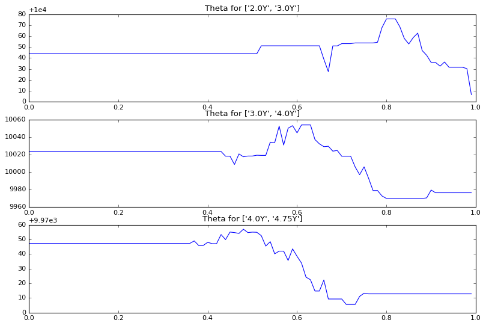

```python
start = 0
end = 1
step = 0.01
fig,ax = plt.subplots(3,1,figsize = (12,8))
theta = np.zeros(3)

for time,res,i in zip(coint_time,result_AR,range(len(coint_time))):
    w,alpha,_,_,ar_res_coint,ar_res_EMA = res
    Coint_res_vec = SampleB[time].dot(w)
    EMA_res_vec = Coint_res_vec-Coint_res_vec.ewm(span=alpha).mean()
    dollar = Grid_Search(Coint_res_vec,EMA_res_vec,ar_res_coint,ar_res_EMA,start=0,end=1,step=0.01)
    theta[i] = np.argmax(dollar)/100.
    print "theta for",time,"is ",np.argmax(dollar)/100.,"max dollar is",max(dollar)
    ax[i].plot(np.arange(start,end,step),dollar)
    ax[i].set_title("Theta for {}".format(time))
```

```python
#calculate for SampleC
for time,res,theta_,i in zip(coint_time,result_AR,theta,range(len(coint_time))):
    w,alpha,_,_,ar_res_coint,ar_res_EMA = res
    Coint_res_vec = SampleC[time].dot(w)
    EMA_res_vec = Coint_res_vec-Coint_res_vec.ewm(span=alpha).mean()
    dollar = calulate_return(theta_,Coint_res_vec,EMA_res_vec,ar_res_coint,ar_res_EMA)[0]
    print time,dollar
```

```
['2.0Y', '3.0Y'] 9978.25021161
['3.0Y', '4.0Y'] 9989.90495615
['4.0Y', '4.75Y'] 10013.0428692
```

```python
#5 calculate the signal quality metrics
def cal_basic_statistics(pnl):
    #hit ratio
    hit_ratio=float(sum(pnl[i]>0 for i in range(len(pnl))))/len(pnl)
    #number of winning week and month
    number_wining=[]
    number_wining.append(float(sum(np.sum(pnl[i:i+5])>0 for i in range(len(pnl)-5) if i%5==0))/(len(pnl)/5))
    number_wining.append(float(sum(np.sum(pnl[i:i+22])>0 for i in range(len(pnl)-22) if i%22==0))/(len(pnl)/22))
    average_profit=np.mean([pnl[i] for i in range(len(pnl)) if pnl[i]>0])
    average_loss=np.mean([pnl[i] for i in range(len(pnl)) if pnl[i]<0])

    return hit_ratio,number_wining,average_profit,average_loss

def calculate_signal_quaility(theta,data1,data2,AR_1,AR_2):
    H =5
    position = 0 #1 for buy,0 for zero,-1 for sell
    count = 0  #if you hold positions, you should not open new ones
    correct_sig = 0
    count_sig = 0
    dollar = 10000
    forecast = np.zeros(data1.shape[0]-H)
    realized = data1.iloc[H:]
    for index in range(data1.shape[0]-H):
        diff = Expected_Gain(theta,data1,data2,AR_1,AR_2,data1.index[index])
        forecast[index] = diff+data1.iloc[index+H]
        if diff>0.001 and position==0:  #0.1 basis point
            count_sig+=1
            dollar += dollar*(data1.iloc[index+H]-data1.iloc[index])/100
            if data1.iloc[index+H]-data1.iloc[index]>0:
                correct_sig+=1
            position=1
        elif diff<-0.001 and position==0:
            count_sig+=1
            if data1.iloc[index+H]-data1.iloc[index]<0:
                correct_sig+=1
            dollar -=dollar*(data1.iloc[index+H]-data1.iloc[index])/100
            position=-1
        elif position==1 or position==-1:
            if count==5: #hold for five days
                position=0
                count = 0
            else:
                count+=1
    return dollar,realized,forecast,float(correct_sig)/count_sig
```

```
hit ratio : 0.401486988848
number of winning(week and month) : [0.39622641509433965, 0.3333333333333333]
average profit : 9.09189744629e-05
average loss : -9.83163824236e-05
['2.0Y', '3.0Y'] correct ratio 0.358974358974


hit ratio : 0.416356877323
number of winning(week and month) : [0.5094339622641509, 0.25]
average profit : 8.44838076423e-05
average loss : -8.87346507579e-05
['3.0Y', '4.0Y'] correct ratio 0.358974358974


hit ratio : 0.472118959108
number of winning(week and month) : [0.5849056603773585, 0.6666666666666666]
average profit : 5.89532767059e-05
average loss : -6.00284535504e-05
['4.0Y', '4.75Y'] correct ratio 0.564102564103
```

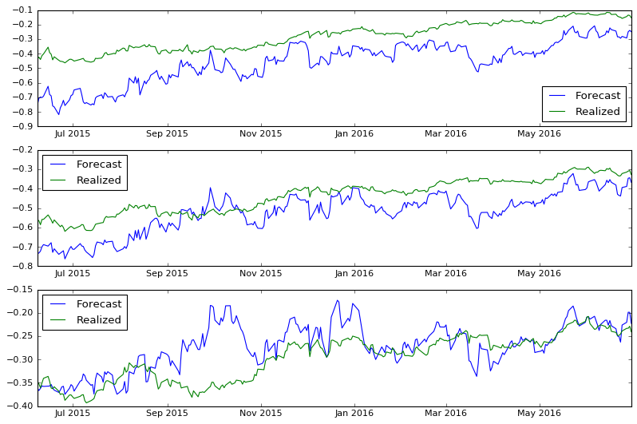

```python
dollar,realized,forecast,corr_ratio = calculate_signal_quaility(theta_,Coint_res_vec,EMA_res_vec,ar_res_coint,ar_res_EMA)
fig,ax = plt.subplots(3,figsize=(12,8))
basic_str=["hit ratio","number of winning(week and month)","average profit","average loss"]

for time,res,theta_,i in zip(coint_time,result_AR,theta,range(len(coint_time))):
    w,alpha,_,_,ar_res_coint,ar_res_EMA = res
    Coint_res_vec = SampleC[time].dot(w)
    EMA_res_vec = Coint_res_vec-Coint_res_vec.ewm(span=alpha).mean()
    pnl = calulate_return(theta_,Coint_res_vec,EMA_res_vec,ar_res_coint,ar_res_EMA)[1]
    basic_stats=cal_basic_statistics((pnl[1:]-pnl[:-1])/pnl[:-1])
    for stat_str,stats_num in zip(basic_str,basic_stats):
        print stat_str,":",stats_num

    dollar,realized,forecast,corr_ratio= calculate_signal_quaility(theta_,Coint_res_vec,EMA_res_vec,ar_res_coint,ar_res_EMA)
    forecast = pd.Series(forecast,index = realized.index)
    ax[i].plot(forecast)
    ax[i].plot(realized)
    ax[i].legend(['Forecast',"Realized"],loc='best')
    print time,"correct ratio",corr_ratio
    print "\n"
```

### 6 Analyze result

- Basically, we get no return in the test sample.
- The reason for that is
  - first, the parameter we use is wrong. In the cross validation and the test sample, it is better for each day to compute an AR model and not use sample A' s parameter.
  - second, when we estimate the theta, it will create the overfitting. This will influence our result.
- The hit ratio and the winning week and month works normal. The correct ratio is terrible since we don't use the correct parameter. *Further Improvement:
  - Make theta a time varying variable
  - Compute AR model dynamically
  - Permorm more signal metrics